# Red Wine Quality Data Analysis

### by Maria Herzer

This data provides information about red wine quality and is publicly available for research. The inputs include objective tests (e.g. PH values) and the output is based on sensory data (median of at least 3 evaluations made by wine experts). Each expert graded the wine quality between 0 (very bad) and 10 (very excellent). Several data mining methods were applied to model these datasets under a regression approach.

P. Cortez, A. Cerdeira, F. Almeida, T. Matos and J. Reis. Modeling wine preferences by data mining from physicochemical properties. In Decision Support Systems, Elsevier, 47(4):547-553. ISSN: 0167-9236.

Available at: [@Elsevier] http://dx.doi.org/10.1016/j.dss.2009.05.016

### Displaying Dataframe:

```
## 'data.frame':    1599 obs. of  15 variables:
##  $ X                   : int  1 2 3 4 5 6 7 8 9 10 ...
##  $ fixed.acidity       : num  7.4 7.8 7.8 11.2 7.4 7.4 7.9 7.3 7.8 7.5 ...
##  $ volatile.acidity    : num  0.7 0.88 0.76 0.28 0.7 0.66 0.6 0.65 0.58 0.5 ...
##  $ citric.acid         : num  0 0 0.04 0.56 0 0 0.06 0 0.02 0.36 ...
##  $ residual.sugar      : num  1.9 2.6 2.3 1.9 1.9 1.8 1.6 1.2 2 6.1 ...
##  $ chlorides           : num  0.076 0.098 0.092 0.075 0.076 0.075 0.069 0.065 0.073 0.071 ...
##  $ free.sulfur.dioxide : num  11 25 15 17 11 13 15 15 9 17 ...
##  $ total.sulfur.dioxide: num  34 67 54 60 34 40 59 21 18 102 ...
##  $ density             : num  0.998 0.997 0.997 0.998 0.998 ...
##  $ pH                  : num  3.51 3.2 3.26 3.16 3.51 3.51 3.3 3.39 3.36 3.35 ...
##  $ sulphates           : num  0.56 0.68 0.65 0.58 0.56 0.56 0.46 0.47 0.57 0.8 ...
##  $ alcohol             : num  9.4 9.8 9.8 9.8 9.4 9.4 9.4 10 9.5 10.5 ...
##  $ quality             : int  5 5 5 6 5 5 5 7 7 5 ...
##  $ wrate               : Ord.factor w/ 3 levels "B"<"G"<"E": 2 2 2 2 2 2 2 2 2 2 ...
##  $ quality.factor      : Factor w/ 6 levels "3","4","5","6",..: 3 3 3 4 3 3 3 5 5 3 ...
```

### Summary of Dataframe:

```
##        X          fixed.acidity   volatile.acidity  citric.acid
##  Min.   :   1.0   Min.   : 4.60   Min.   :0.1200   Min.   :0.000
##  1st Qu.: 400.5   1st Qu.: 7.10   1st Qu.:0.3900   1st Qu.:0.090
##  Median : 800.0   Median : 7.90   Median :0.5200   Median :0.260
##  Mean   : 800.0   Mean   : 8.32   Mean   :0.5278   Mean   :0.271
##  3rd Qu.:1199.5   3rd Qu.: 9.20   3rd Qu.:0.6400   3rd Qu.:0.420
##  Max.   :1599.0   Max.   :15.90   Max.   :1.5800   Max.   :1.000
##  residual.sugar     chlorides       free.sulfur.dioxide total.sulfur.dioxide
##  Min.   : 0.900   Min.   :0.01200   Min.   : 1.00       Min.   :  6.00
##  1st Qu.: 1.900   1st Qu.:0.07000   1st Qu.: 7.00       1st Qu.: 22.00
##  Median : 2.200   Median :0.07900   Median :14.00       Median : 38.00
##  Mean   : 2.539   Mean   :0.08747   Mean   :15.87       Mean   : 46.47
##  3rd Qu.: 2.600   3rd Qu.:0.09000   3rd Qu.:21.00       3rd Qu.: 62.00
##  Max.   :15.500   Max.   :0.61100   Max.   :72.00       Max.   :289.00
##     density             pH          sulphates         alcohol
##  Min.   :0.9901   Min.   :2.740   Min.   :0.3300   Min.   : 8.40
##  1st Qu.:0.9956   1st Qu.:3.210   1st Qu.:0.5500   1st Qu.: 9.50
##  Median :0.9968   Median :3.310   Median :0.6200   Median :10.20
##  Mean   :0.9967   Mean   :3.311   Mean   :0.6581   Mean   :10.42
##  3rd Qu.:0.9978   3rd Qu.:3.400   3rd Qu.:0.7300   3rd Qu.:11.10
##  Max.   :1.0037   Max.   :4.010   Max.   :2.0000   Max.   :14.90
##     quality      wrate    quality.factor
##  Min.   :3.000   B:  63   3: 10
##  1st Qu.:5.000   G:1518   4: 53
##  Median :6.000   E:  18   5:681
##  Mean   :5.636            6:638
##  3rd Qu.:6.000            7:199
##  Max.   :8.000            8: 18
```

I ran a couple of commands to examine the data loaded from the dataset.

### Initial Univariate investigation

Initially I ran some commands to produce histograms of the various elements to see how they were distributed.

### Here are the values which are skewed and have a non standard distribution

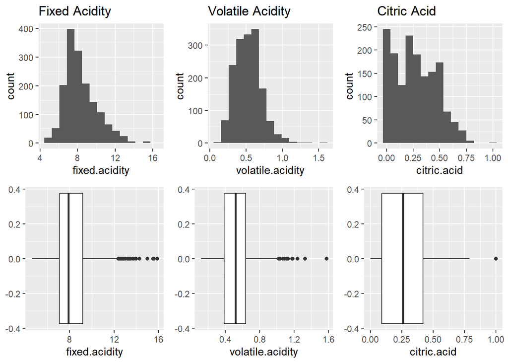

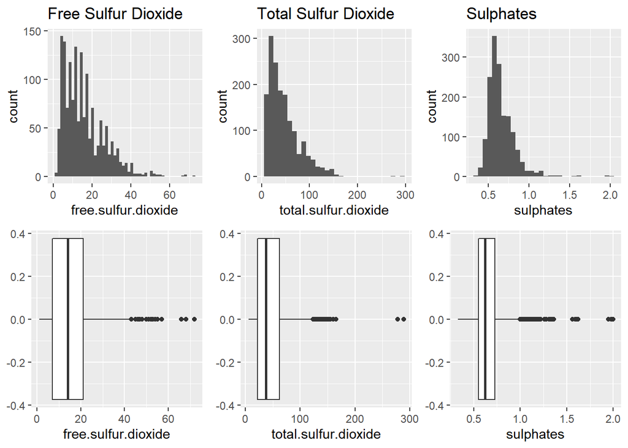

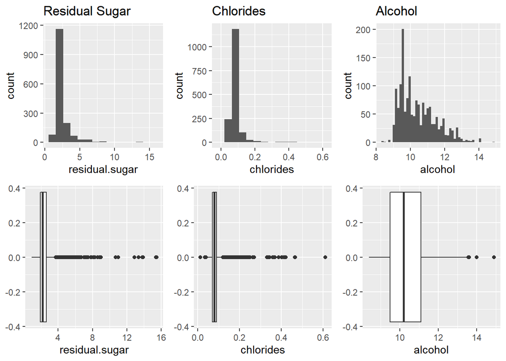

I then tried transforming these quantities and graphed them to the log function. You can see below that most of the histograms using the log function show a more evenly distributed histograms however Citric Acid is greatly skewed as is alcohol.

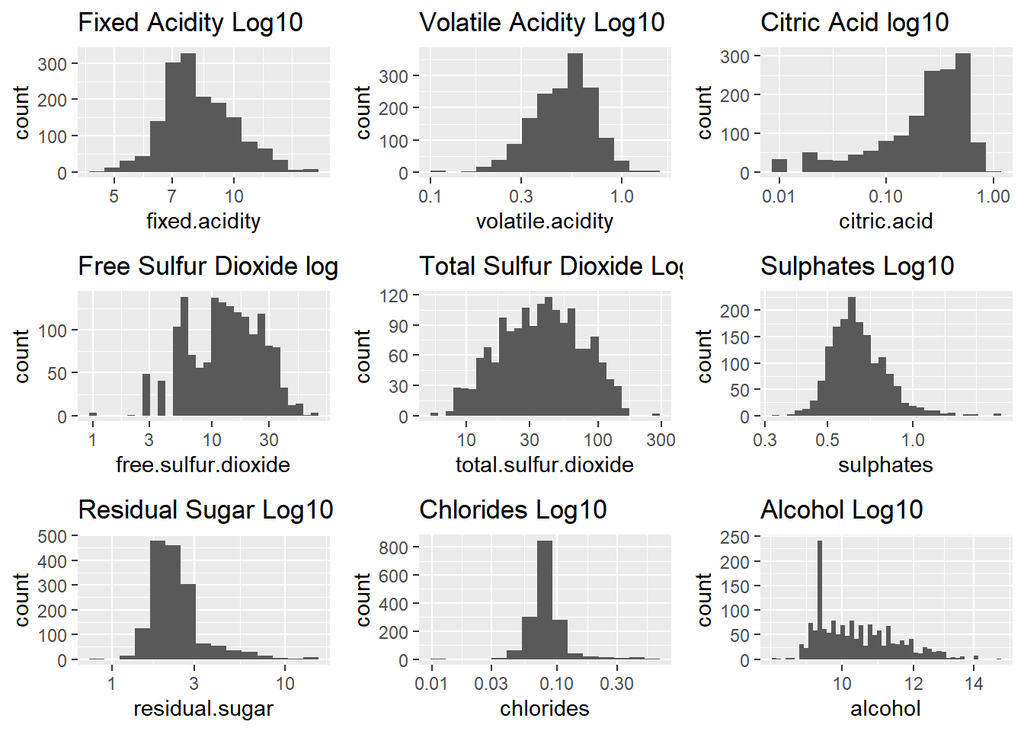

### Here are values that did show standard distributions.

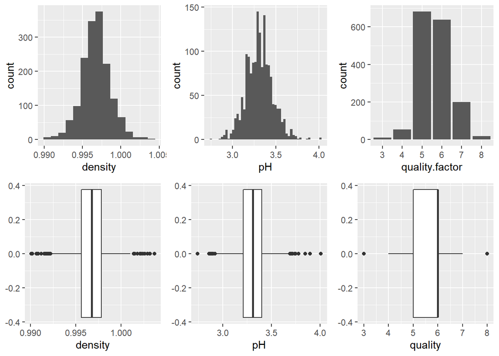

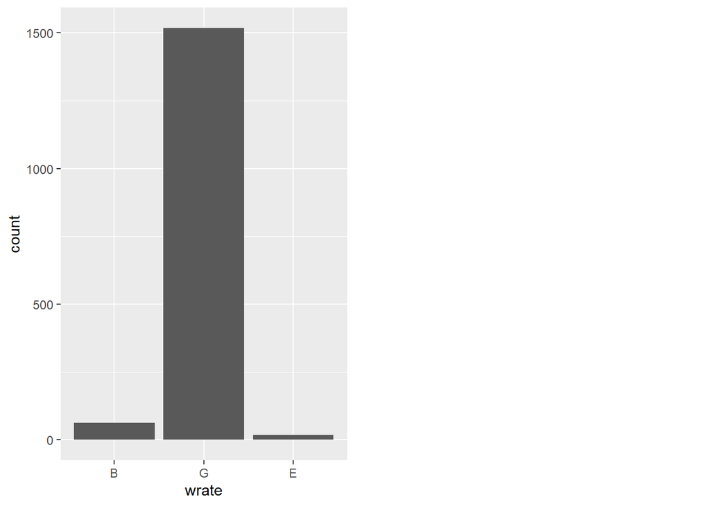

# Univariate Analysis

### What is the structure of your dataset?

The dataset has 1599 objects with 13 variables. It includes Fixed acidity, volatile acidity, citric acid, residual sugar, chlorides, fee sulfur dioxide , total sulfur dioxide density and PH and alcohol all components in the wine. The data also includes Quality which is a rating for each of the wines. There is also an X variable which is just an index for each of the entries so there will be no need to examine this variable.

### What is/are the main feature(s) of interest in your dataset?

I would like to see if there are any relationship in the various variables of the wine and which qualities are related to better quality. Since most of the wines are in the 5 to 6 range I would like to see what qualities are most prevalent in this range. as well as the ratings above 6 which would be average or better wines.

### Did you create any new variables from existing variables in the dataset?

I created a factor wrate with 3 divisions to divide between what would be considered good wines with a quality of 5 or better as well as transformed the quality variable into a factor to better compare the average values in the bivariate plot later on. In the Univariate plot I did of the wrate variable I can see that almost all wines are of good quality with very few excellent wines.

### Did you perform any operations on the data to tidy, adjust, or change the form of the data? If so, why did you do this?

I did not perform any operations to tidy the data but did add some additional variables as factors to better plot the data.

# Bivariate Plots Section

I would like to take a look at quality vs the different values of the components to see which ones are may correlate with the higher qualities. I originally wanted to see how to predict better wines but see that the data overwhelmingly shows average quality wines so this may not be something as easy to do.

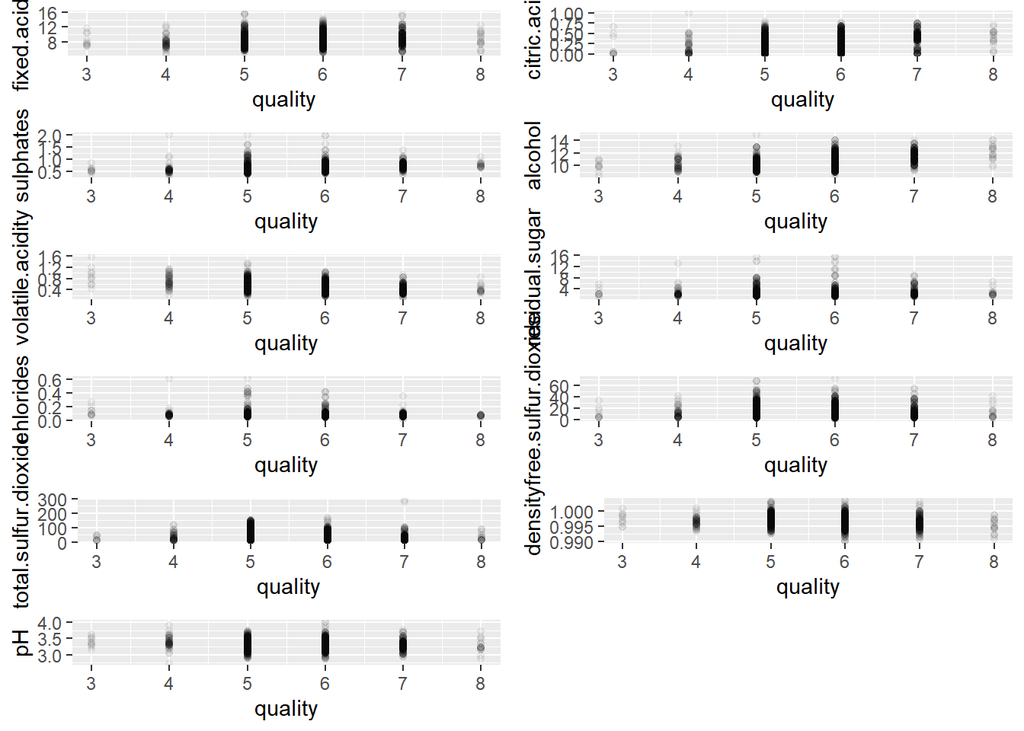

I plotted a set of scatter plots to see the relationship between quality and the components but they seem overplotted and were not very helpful so I decided to make box plots showing the median values of each of the components as well as outliers.

### Graphs showing linear increases for better quality.

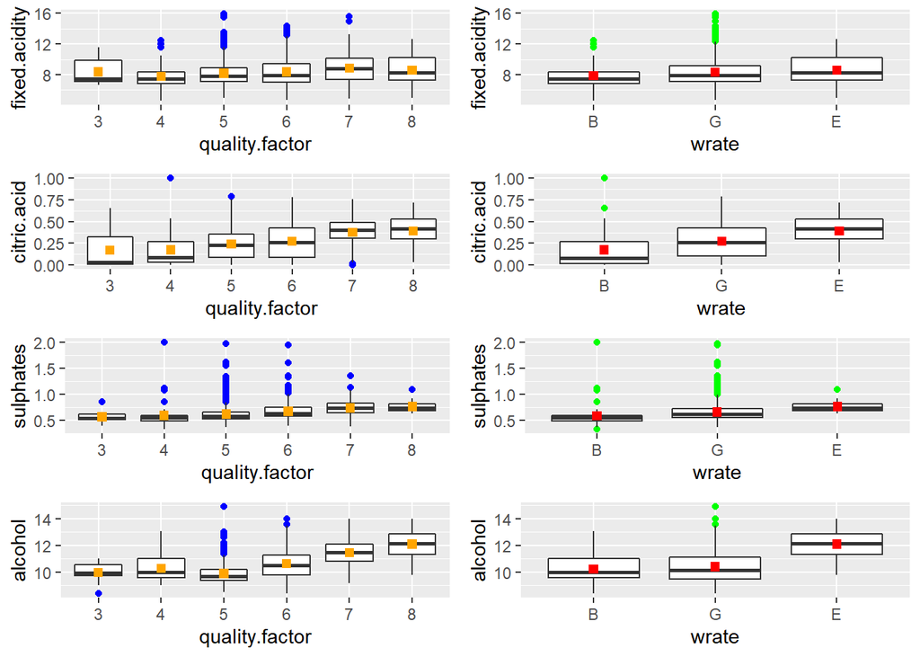

The above graphs showed compounds that had an increase for wines with higher quality. There wer four components that seemed to have an increase. Fixed.Acidity Citric Acid Sulphates and Alcohol.

### Graphs with very little variance

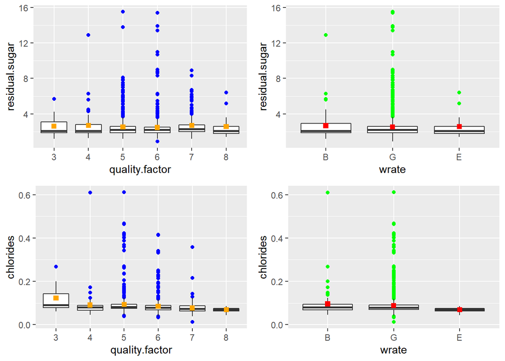

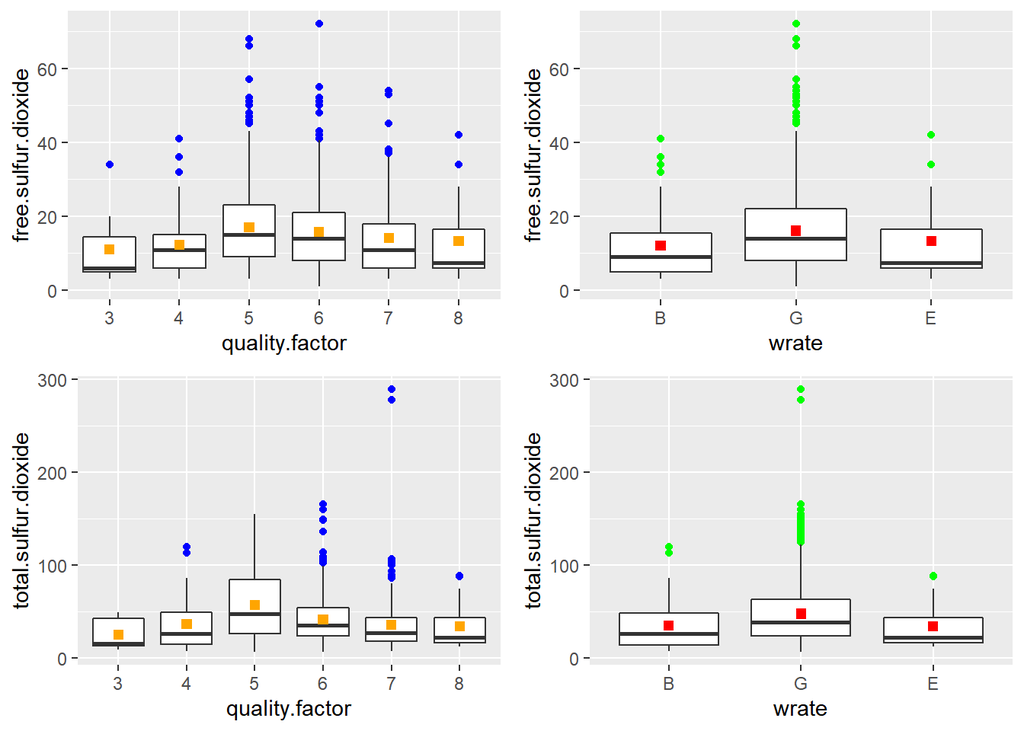

Ther are some components that show very little change vs quality.

### Graphs with decrease

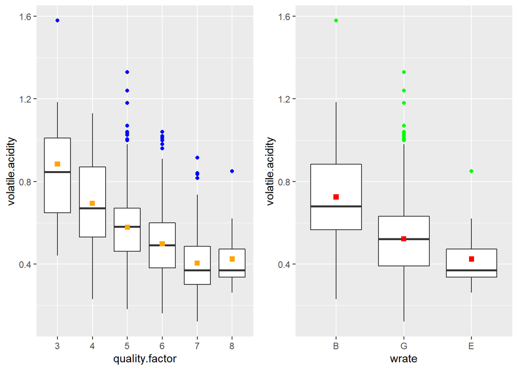

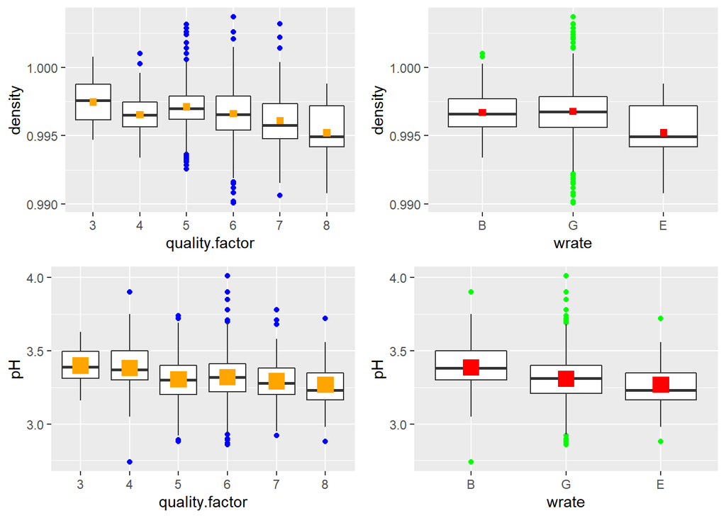

# Bivariate Analysis

### Talk about some of the relationships you observed in this part.

In plotting the different components vs quality I found that a couple of components seem to show some increase for greater quality such as alcohol, fixed acidity, citric acid and sulphates.

### Did you observe any interesting relationships between the other features

It interesting that the PH seems to decrease in greater quality wines as they are more acidic but the volatile acidity also seems to decrease which would mean this the volatile acidity is not contributing to the PH but Citric Acid

I noticed that Chlorines and the free and total sulfur dioxide have almost no difference with any change in quality and they may not affect the PH values and acidity either.

# Multivariate Plots Section

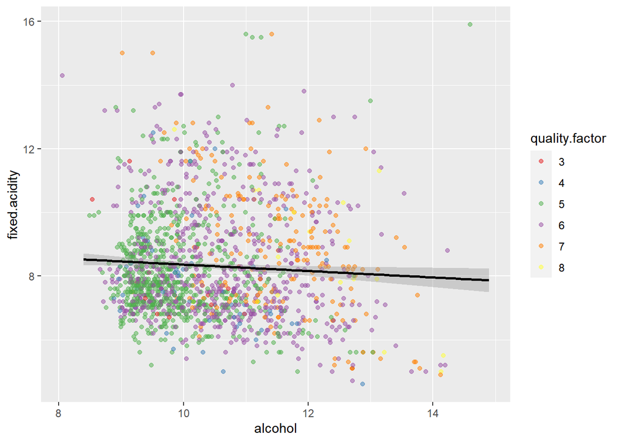

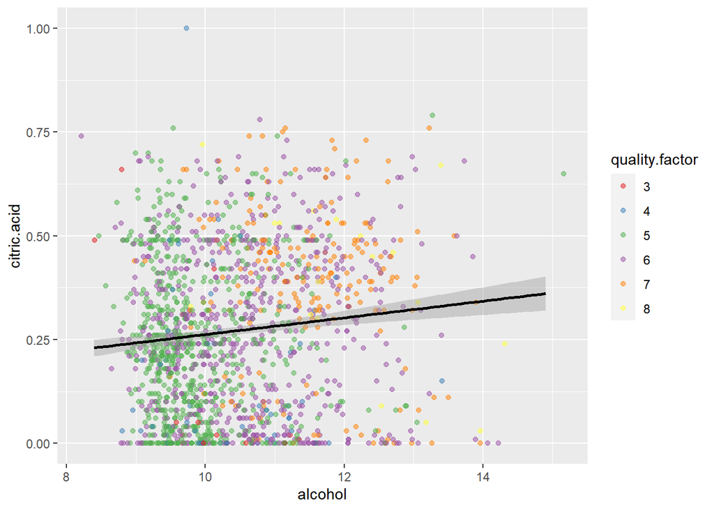

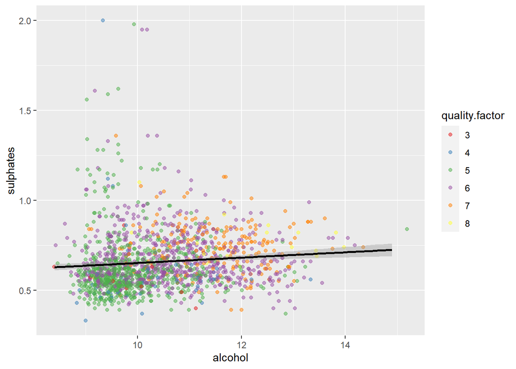

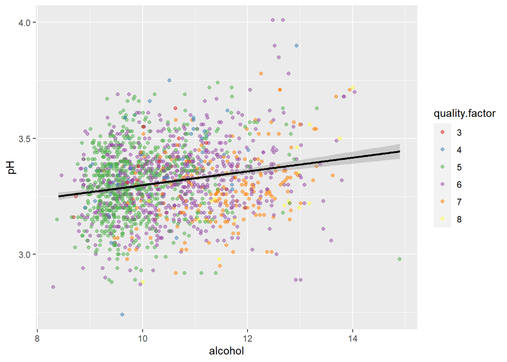

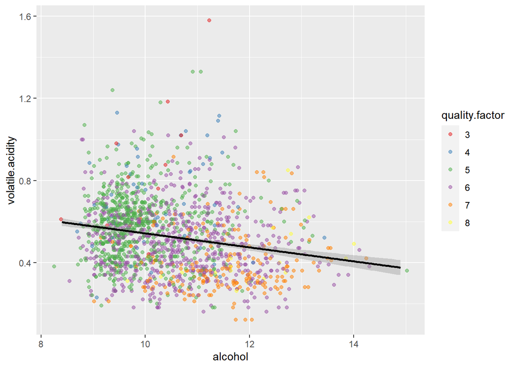

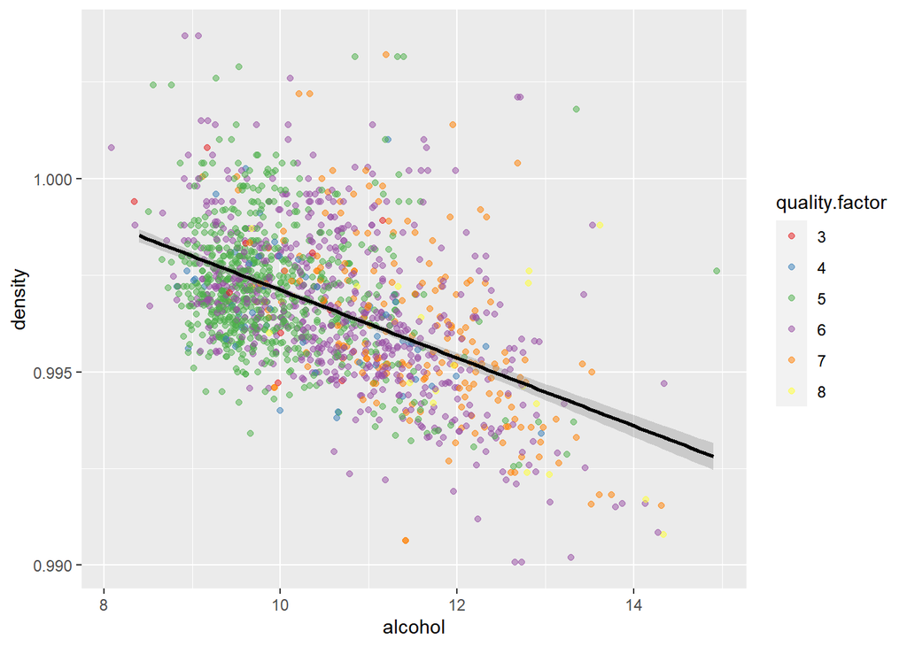

The above graphs showed a negative correlation as the alcohol increased in the graphs there was a decrease both in density and also the volatile acidity. After seeing these graphs I also wished to look at the relation of PH to acidity

PH Graph

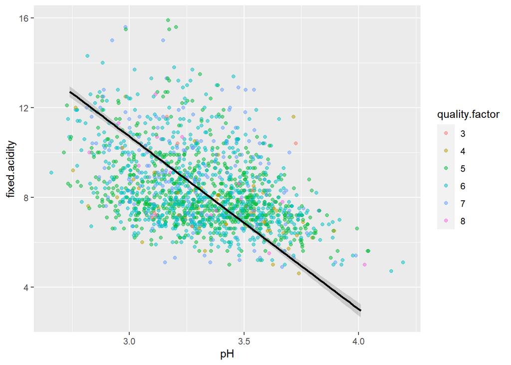

# Multivariate Analysis

When plotting the scatterplots of Alcohol vs citric acid as well as Alcohol vs acidity seemed both be higher for the better quality wines.

# Final Plots and Summary

These final plots show what we summarized from the data with the plotting and graphs done. We can see that there are some somewhat weak relationships with components that show up for higher quality wines.

### Plot One

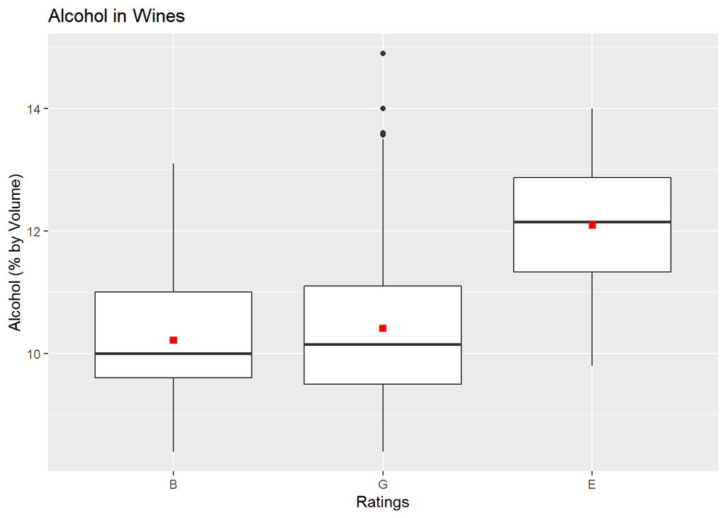

### Description One

In this first plot I chose the box plot of Alcohol to wine rating. It shows a correlation that higher quality wines have a higher alcohol rating. It seems that the Excellent wines that are labeled jumped by 2% volume of Alcohol.

### Plot Two

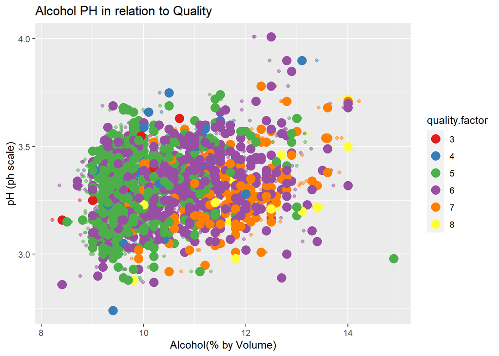

### Plot Three

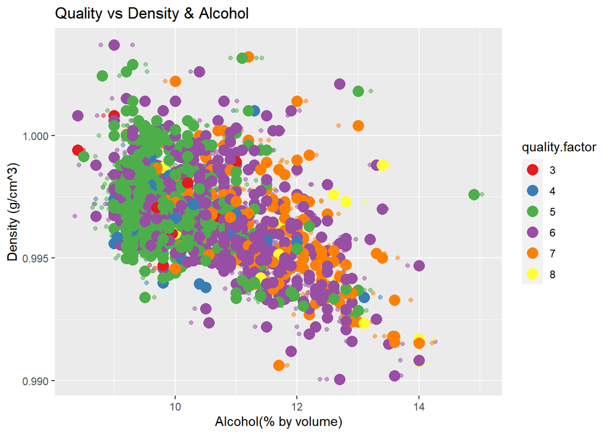

### Description Three

The third graph above shows a relationship between Alcohol and Density to quality.The wines with higher Alcohol content in most cases seem to have a lower density. I think this would be expected as Alcohol does have a lower density than water.These wines would have a higher quality as it with previous plots its shown that the wines with higher Alcohol volume do have higher quality.

# Reflection

To try and build a model to predict the components of higher quality wine I think I would need to get additional data from other wines. I would like to get a more varied dataset with a higher quantity of Excellent wines to compare with the Average wines and see if the data provided is more than just due to outliers of the small quanity of higher quality wines provided.

References used:

https://www.datanovia.com/en/lessons/compute-and-add-new-variables-to-a-data-frame-in-r/ https://bookdown.org/ndphillips/YaRrr/dataframe-column-names.html

https://stackoverflow.com/questions/18413756/re-ordering-factor-levels-in-data-frame#comment82042419_18414263

https://stackoverflow.com/questions/35412297/combine-histogram-with-scatter-plot-in-r

https://stackoverflow.com/questions/22074164/scatter-plot-and-boxplot-overlay

https://sebastiansauer.github.io/ggplot-summaries/

https://knowledge.udacity.com/questions/227421

https://spiritswinecellar.com/components-of-wine/

https://waterhouse.ucdavis.edu/whats-in-wine/red-wine-composition

https://little-book-of-r-for-multivariate-analysis.readthedocs.io/en/latest/src/multivariateanalysis.html#:~:text=%20Using%20R%20for%20Multivariate%20Analysis%20%C2%B6%20,step%20is…%204%20Contact%20%C2%B6.%20%20More